# Sampling 3D Simulation (truck)

Xianbin Cheng

09/17/2020

# Objective

To analyze data from 10,000 iterations of 3D simulation in a 3m x 2m x 1.5m truck (without parallelization).

# Method

1. Necessary inputs

```r
library(kableExtra)
library(sensitivity)
source(file = "Sampling_libraries.R")
source(file = "Sampling_contamination.R")
source(file = "Sampling_contamination_3d.R")
source(file = "Sampling_visualization.R")
source(file = "Sampling_assay_prep.R")
source(file = "Sampling_plan.R")
source(file = "Sampling_plan_3d.R")
source(file = "Sampling_assay_3d.R")
source(file = "Sampling_assay.R")
source(file = "Sampling_outcome_3d.R")
source(file = "Sampling_outcome.R")
source(file = "Sampling_iteration.R")
source(file = "Sampling_tuning_3d.R")
source(file = "Sampling_analysis.R")
```

```r
# Important parameters
homogeneity = 0.1
Mc = 20

# Iteration
n_iter = 100
n_seed = 100

# Experiment 1
n_sp = 7

# Experiment 2
method_sp = "srs"

# Parameter tuning
c_hat_vec = c(5, 10, 20, 40, 80, 100)
n_affected_vec = c(1, 10, 100, 1000)
n_sp_vec = c(5, 10, 100)
method_sp_vec = c("srs", "strs", "ss")
```

2. Load all the RDS files and clean them up.

```r
# Get the RDS file names
rds_files = dir(path = paste0(getwd(), "/RDS/3D Simulation"),pattern = "3x2x1.5", full.names = TRUE)

# Read rds files
exp1 = map(.x = str_subset(string = rds_files, pattern = "srsxstrsxss"), .f = readRDS)
exp2 = map(.x = str_subset(string = rds_files, pattern = "srsxstrsxss", negate = TRUE), .f = readRDS)

# Clean up the rds files into csv files
exp1_cleaned = f_clean_up(data = exp1, vals_prim = c_hat_vec, vals_sec = method_sp_vec, vals_tert = n_affected_vec, n_seed = n_seed)

exp2_cleaned = f_clean_up(data = exp2, vals_prim = c_hat_vec, vals_sec = n_sp_vec, vals_tert = n_affected_vec, n_seed = n_seed)
```

| experiment | c_hat | homogeneity | n_sp | method_sp | n_affected | n_seed | n_iter |
| --- | --- | --- | --- | --- | --- | --- | --- |
| 1 | 5,10,20,40,80,100 | 0.1 | 7 | srs,strs,ss | 1,10,100,1000 | 100 | 100 |
| 2 | 5,10,20,40,80,100 | 0.1 | 5,10,100 | srs | 1,10,100,1000 | 100 | 100 |

2. Further summarizing of the data to produce OC curves

```r
exp_combined = f_combine(data1 = exp1_cleaned, data2 = exp2_cleaned, exp1_param = n_sp, exp2_param = method_sp)
```

3. Sensitivity analysis

```r
# Experiment all
sens_all = sensitivity::pcc(X = subset(x = exp_combined, select = c("method_sp", "n_affected", "n_sp", "c_hat")),
                            y = exp_combined$Paccept,
                            rank = TRUE,
                            nboot = 100,
                            conf = 0.95)
```

4. Comparison of slopes at 20 ppb.
- Intuition: We can’t directly calculate the slope at 20 ppb because we don’t have a differentiable OC curve. Since we have discrete data points at 10, 20, 40 ppb, we can first calculate the slope of each OC curve between 10 and 20 ppb, and then calculate the slope between 20 and 40 ppb. Finally, we take the average and treat it as an estimate of the slope at 20 ppb.

$$slope=\frac{1}{2n}\times (\sum_{j=1}^n\frac{P_{10j}-P_{20j}}{10-20}+\sum_{j=1}^n\frac{P_{20j}-P_{40j}}{20-40})$$
, where $P_{ij}=$ acceptance probability at $i^{th}$ concentration for $j^{th}$ OC curve, $n=$ `n_seed`.

```r
slopes_exp1 = calc_mean_slope2(data = exp_combined, Mc = Mc, c_hat_vec = c_hat_vec, experiment = 1,
                               method_sp_vec = method_sp_vec, n_affected_vec = n_affected_vec)
slopes_exp2 = calc_mean_slope2(data = exp_combined, Mc = Mc, c_hat_vec = c_hat_vec, experiment = 2,
                               n_sp_vec = n_sp_vec, n_affected_vec = n_affected_vec)
```

5. Comparison of mean acceptance probabilities at 20 ppb.

```r
# Get the p-value for anova of mean difference in Paccept at 20 ppb.
# param2 == method_sp or n_sp, param3 == n_affected
calc_pval_anova = function(data, fix, val){
  if(fix == "param3"){
    mod = aov(formula = Paccept ~ as.factor(param2),
              data = subset(x = data, subset = (param == 20) & (param3 == val)))
  } else if (fix == "param2"){
    mod = aov(formula = Paccept ~ as.factor(param3),
              data = subset(x = data, subset = (param == 20) & (param2 == val)))
  }

  return(summary(mod)[[1]]$`Pr(>F)`[1])
}

summarize_pval = function(data, param_tune_vec, fix){

  pvals = sapply(X = param_tune_vec, FUN = calc_pval_anova, data = data, fix = fix)
  result = data.frame(param_tune = param_tune_vec, pval = pvals)
  return(result)
}
```

# Results

1. Visualization: Experiment 1

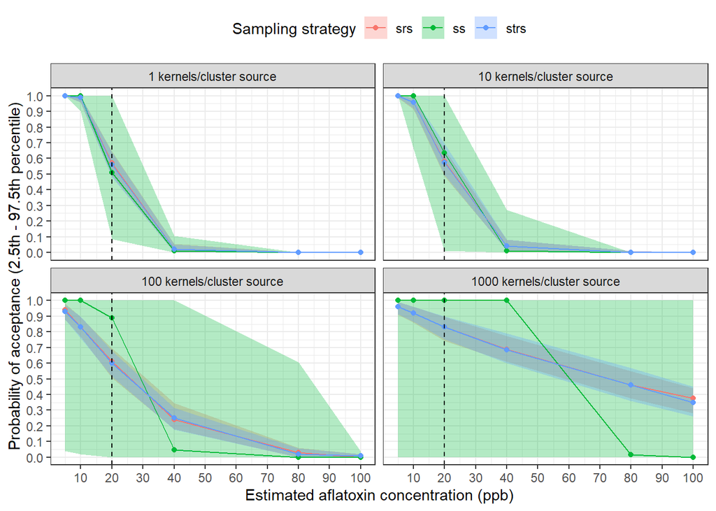

```
##    method_sp n_affected      slope
## 1        srs          1 -0.0346700
## 2       strs          1 -0.0348325
## 3         ss          1 -0.0353100
## 4        srs         10 -0.0322950
## 5       strs         10 -0.0323775
## 6         ss         10 -0.0324300
## 7        srs        100 -0.0199625
## 8       strs        100 -0.0201875
## 9         ss        100 -0.0190600
## 10       srs       1000 -0.0076475
## 11      strs       1000 -0.0080900
## 12        ss       1000 -0.0066075
```

2. Visualization: Experiment 2

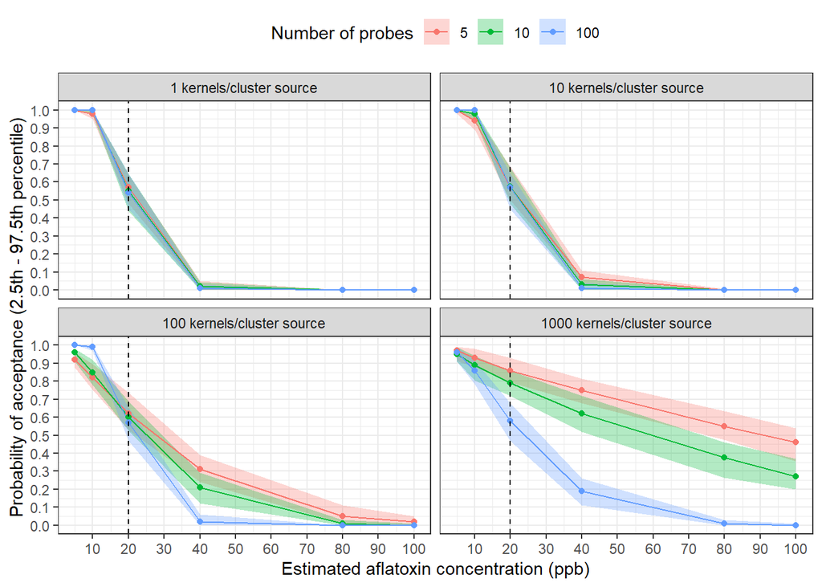

```
##    n_sp n_affected      slope
## 1     5          1 -0.0341325
## 2    10          1 -0.0355150
## 3   100          1 -0.0361150
## 4     5         10 -0.0308150
## 5    10         10 -0.0336350
## 6   100         10 -0.0356025
## 7     5        100 -0.0178700
## 8    10        100 -0.0222375
## 9   100        100 -0.0344375
## 10    5       1000 -0.0062850
## 11   10       1000 -0.0091275
## 12  100       1000 -0.0238325
```

3. Sensitivity tornado plot

```
##
## Call:
## sensitivity::pcc(X = subset(x = exp_combined, select = c("method_sp",     "n_affected", "n_sp", "c_hat")), y = exp_combined$Paccept,     rank = TRUE, nboot = 100, conf = 0.95)
##
## Partial Rank Correlation Coefficients (PRCC):
##               original          bias  std. error   min. c.i.   max. c.i.
## method_sp   0.04141436 -0.0003604240 0.008296063  0.02425045  0.05681734
## n_affected  0.28421308 -0.0004965899 0.007504135  0.27009976  0.30178171
## n_sp       -0.09442844 -0.0001011248 0.007150793 -0.10847075 -0.08204148
## c_hat      -0.87002517  0.0001545463 0.002512019 -0.87590873 -0.86513257
```

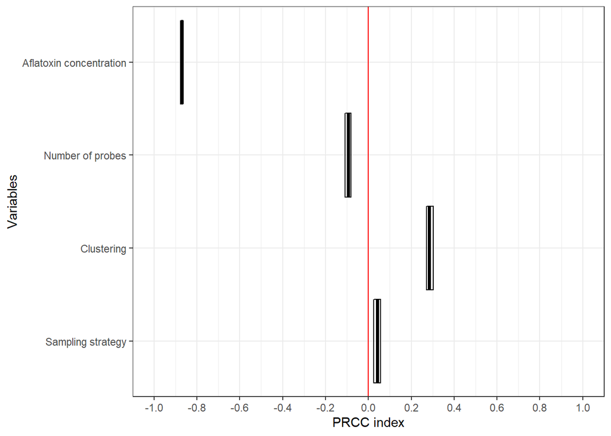

4. Summary of the mean acceptance probabilities at 20 ppb

```r
# Experiment 1
summary_exp1 = exp1_cleaned %>%
  dplyr::filter(param == 20) %>%
  group_by(param3, param2) %>%
  summarize(mean_Paccept = mean(Paccept))
summary_exp1
```

```
## # A tibble: 12 x 3
## # Groups:   param3 [4]
##    param3 param2 mean_Paccept
##     <int> <chr>         <dbl>
##  1      1 srs           0.569
##  2      1 ss            0.546
##  3      1 strs          0.562
##  4     10 srs           0.580
##  5     10 ss            0.595
##  6     10 strs          0.582
##  7    100 srs           0.610
##  8    100 ss            0.621
##  9    100 strs          0.600
## 10   1000 srs           0.828
## 11   1000 ss            0.783
## 12   1000 strs          0.829
```

```r
summarize_pval(data = exp1_cleaned, fix = "param3", param_tune_vec = n_affected_vec)
```

```
##   param_tune      pval
## 1          1 0.6455885
## 2         10 0.8624832
## 3        100 0.8359175
## 4       1000 0.2900402
```

```r
summarize_pval(data = exp1_cleaned, fix = "param2", param_tune_vec = method_sp_vec)
```

```
##      param_tune          pval
## srs         srs 4.230428e-157
## strs       strs 2.367576e-162
## ss           ss  5.477450e-05
```

```r
# Experiment 2
summary_exp2 = exp2_cleaned %>%
  dplyr::filter(param == 20) %>%
  group_by(param3, param2) %>%
  summarize(mean_Paccept = mean(Paccept))
summary_exp2
```

```
## # A tibble: 12 x 3
## # Groups:   param3 [4]
##    param3 param2 mean_Paccept
##     <int>  <int>        <dbl>
##  1      1      5        0.563
##  2      1     10        0.550
##  3      1    100        0.545
##  4     10      5        0.578
##  5     10     10        0.574
##  6     10    100        0.562
##  7    100      5        0.624
##  8    100     10        0.604
##  9    100    100        0.572
## 10   1000      5        0.862
## 11   1000     10        0.789
## 12   1000    100        0.575
```

```r
summarize_pval(data = exp2_cleaned, fix = "param3", param_tune_vec = n_affected_vec)
```

```
##   param_tune          pval
## 1          1  2.513523e-02
## 2         10  7.193113e-02
## 3        100  2.764721e-12
## 4       1000 2.434202e-137
```

```r
summarize_pval(data = exp2_cleaned, fix = "param2", param_tune_vec = n_sp_vec)
```

```
##   param_tune          pval
## 1          5 6.810092e-178
## 2         10 2.692366e-133
## 3        100  9.126594e-05
```

5. Quality control figures that show how much the output concentration deviates from the input concentration.

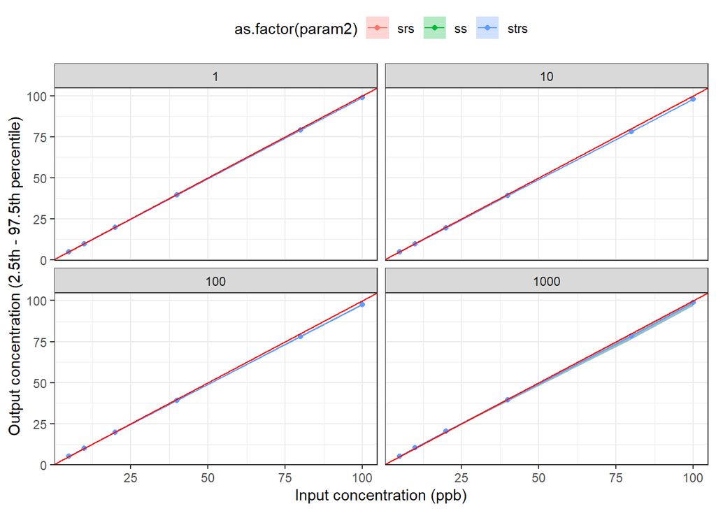

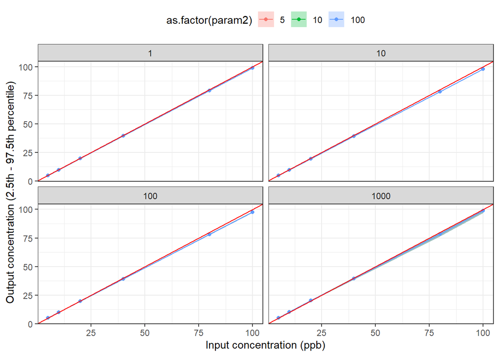

# Retired code

ANOVA for `Paccept` ~ `method_sp`/`n_sp` under different `n_affected`

```r
pval1 = split(x = exp1_cleaned, f = exp1_cleaned$param3) %>%
  map(.x = ., .f = get_pval, form = Paccept ~ as.factor(param2))

pval2 = split(x = exp2_cleaned, f = exp2_cleaned$param3) %>%
  map(.x = ., .f = get_pval, form = Paccept ~ as.factor(param2))

pval_all = rbind.data.frame(bind_cols(pval1), bind_cols(pval2)) %>%
  mutate(experiment = c(1, 2), formula = c("Paccept ~ as.factor(method_sp)", "Paccept ~ as.factor(n_sp)"), c_hat = 20) %>%
  gather(data = ., key = "n_affected", value = "p.value", -c(experiment, formula, c_hat)) %>%
  dplyr::arrange(experiment)
```